# Draw China Maps with `cnmap()`

2019-06-27 23:12:09

# 1 Introduction

You can always use `package:ggplot2` to draw maps. But when it comes to China maps, you might have a difficult time in getting map data. This document is to guide you to draw province-level and city-level China maps more easily.

We provided four datasets in the `package:asesgeo` package covering the four administrative levels (nation, province/municipality, prefecture, county/district). You can easily call them by function `cnmap()`. Compared to conventional China map datasets in packages such as `package:maps`, `package:mapdata` and other open-source data such as GADM [^1], `cnmap()` has a couple of advantages:

- **More complete**. The map in `package:maps` does not contain Taiwan, and only provides nationwide borders.
- **More up-to-date**. The map in `package:mapdata` does not contain Chongqing.
- **More precise**. The map by GADM does not have an accurate border in Tibet and Xinjiang.

## 1.1 How to Use

You can load `package:asesgeo` and then call `?cnmap` to read the manual. When calling `cnmap()`, it will load one of the four embeded datasets (nation-level `chnmap0`, province-level `chnmap1`, prefecture-level `chnmap2`, and county-level `chnmap3`).

## 1.2 Structure of the Map Datasets

All the four datasets are of `sp::SpatialPolygonsDataFrame` class. As S4 objects, they are comprised of 5 slots:

1. **data** [*data.frame*]: the meta data of the map object
2. **polygons** [*list*]: a list of `sp::Polygons` objects lengthing the number of rows of the metadata data.frame. Each list contains 5 slots:
   1. **Polygons** [*list*]: a list of `sp::Polygon` objects. Each list contains 5 slots:
      1. latpt [*numeric vector*]: the coordinate pair of the centroid point
      2. area [*numeric scalar*]: the area of the polygon
      3. hole [*logical scalar*]: whether the polygon is a hole
      4. ringDir [*integer scalar*]: -1 or 1
      5. coords [*numeric matrix*]: point pairs of the polygon, each point in a row
   2. **plotOrder** [*integer vector*]: the order to plot the polygons, lengthing the count of the Polygons.
   3. **labpt** [*numeric vector*]: : the coordinate pair of the centroid point
   4. **ID** [*character scalar*]: ID of the Polygons. All the IDs should be align with the row.names of the metadata data.frame.
   5. **area** [*numeric scalar*]: the total area of the Polygons
3. **plotOrder** [*integer vector*]: the order to plot the polygons, lengthing the count of the Polygons.
4. **bbox** [*numeric matrix*]: the coordinate limits of the map
5. **proj4string** [*CRS string*]: the PROJ.4 definition of the map

## 1.3 Structure of the Map Metadata

The structure of the four datasets:

```
## Welcome to asesgeo 0.1.0
```

```
## 'data.frame':    1 obs. of  9 variables:
##  $ ID       : chr "0"
##  $ NAME     : chr "中华人民共和国"
##  $ PERIMETER: num 475
##  $ AREA     : num 962
##  $ NAME_LAB : chr "中国"
##  $ NAME_EN  : chr "China"
##  $ ADCODE   : chr ""
##  $ PTX      : num 104
##  $ PTY      : num 36.6
## 'data.frame':    34 obs. of  9 variables:
##  $ ID       : chr  "0" "1" "2" "3" ...
##  $ NAME     : chr  "安徽省" "澳门特别行政区" "北京市" "福建省" ...
##  $ PERIMETER: num  34.793 0.471 10.115 50.133 88.246 ...
##  $ AREA     : num  13.3528 0.00297 1.73481 11.03721 43.61226 ...
```

[output cut: 29 more lines]

There are some important fields in common:

**Table 1-1-1**: Key Fields in the Metadata

| Field | Type | Implication |
| --- | --- | --- |
| ID | chr | Identifier of each row. Note that `row.names` of the metadata is aligned with the IDs of the polygons |
| NAME | chr | Full Chinese name of each Polygons object |
| NAME_EN | chr | Short English name of each Polygons object |
| NAME_LAB | chr | Short Chinese name of each Polygons object |
| ADCODE | chr | 6-digit administrative code in ‘aabbcc’ format (aa: province code; bb: prefecture code; cc: county code). E.g., 110000 for ‘Beijing’ municipality, ‘110101’ for ‘Dongcheng, Beijing’. |
| AREA | num | Total area of the Polygons |
| PERIMETER | num | Total perimeter of the Polygons |
| PTX | num | Longitude (x-coordinate) of the centroid point |
| PTY | num | Lattitude (y-coordinate) of the centroid point |

## 1.4 Fetch More Data

- Visit [GADM site](http://gadm.org) to get more datasets;
- Download R datasets you want;
- Use `readRDS` to read the S4 object from the rds file;
- Use `broom::tidy` function to extract polygon data from the S4 object;
- `<object name>@data` is the meta data.

> Note that the GADM certificate forbids commercial use. And the borders are not aligned with Chinese official data.

# 2 Base Maps

Either `geom_map`, `geom_polygon` or `geom_sf` can be used to plot maps [^2].

## 2.1 Level-0 (Nation) Base Map

Use dataset `chnmap0` to draw a level-0 China base map.

### 2.1.1 Using `maps::map()`

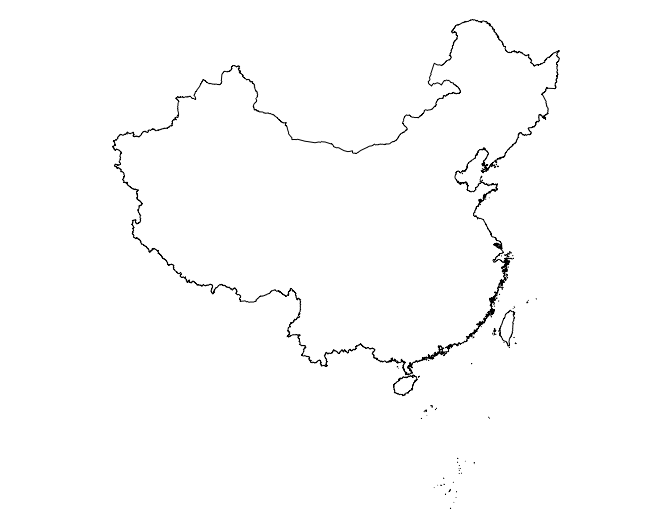

**Figure 2-1-1**: China Base Map by `map` (Nation Level)

```r
library(maps)
op <- par(mar=c(0, 0, 0, 0))
map(cnmap0(), projection="albers", parameters=c(24, 47))
```

```r
par(op)
```

### 2.1.2 Using `ggplot2::geom_map()` or `ggplot2::geom_polygon()`

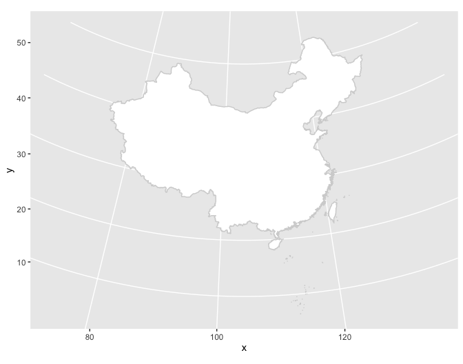

**Figure 2-1-2**: China Base Map by `geom_map` (Nation Level)

```r
library(ggplot2)
map0 <- fortify(cnmap0())
ggplot(data=map0, aes(map_id=id)) +
    geom_map(map=map0, fill='white', colour='lightgray') +
    expand_limits(x=map0$long, y=map0$lat) +
    coord_map(projection="albers", parameters=c(24, 47))
```

The syntax could also be upgrade to a more extendable form:

```r
map0 <- fortify(cnmap0())
ggplot() +
    geom_map(aes(map_id=id), data=map0, map=map0, fill='white', colour='lightgray') +
    expand_limits(x=map0$long, y=map0$lat) +
    coord_map(projection="albers", parameters=c(24, 47))
```

or even easier, with `geom_polygon()`:

```r
map0 <- fortify(cnmap0())
ggplot() +
    geom_polygon(aes(x=long, y=lat, group=group), data=map0, fill='white',
                 colour='lightgray') +
    coord_map(projection="albers", parameters=c(24, 47))
```

### 2.1.3 Using `ggplot2::geom_sf()`

```r
chn_crs <- "+init=epsg:4490 +proj=laea +ellps=GRS80 +lon_0=105 +lat_0=30"
library(sf)
```

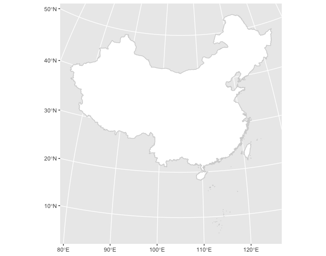

**Figure 2-1-3**: China Base Map by `geom_sf` (Nation Level)

```r
map0 <- st_as_sf(cnmap0())
ggplot() +
    geom_sf(data=map0, fill='white', colour='lightgray') +
    coord_sf(crs=chn_crs)
```

## 2.2 Level-1 (Province) Base Map

Use dataset `chnmap1` to draw a level-1 China base map. You can use its metadata to show the name labels over the polygons.

```r
library(extrafont)
```

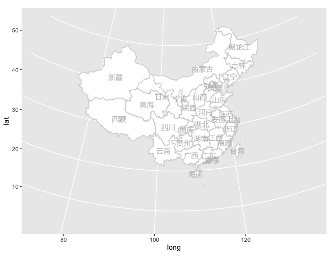

**Figure 2-2-1**: China Base Map by `geom_polygon` (Province Level)

```r
map1 <- fortify(cnmap1())
meta1 <- cnmap1()@data
ggplot() +
    geom_polygon(aes(x=long, y=lat, group=group), data=map1, fill='white',
                 colour='lightgray') +
    geom_text(aes(PTX, PTY, label=NAME_LAB), data=meta1, colour='gray',
              family="Microsoft YaHei") +
    coord_map(projection="albers", parameters=c(24, 47))
```

Or use `geom_sf` coupled with `package:sf`.

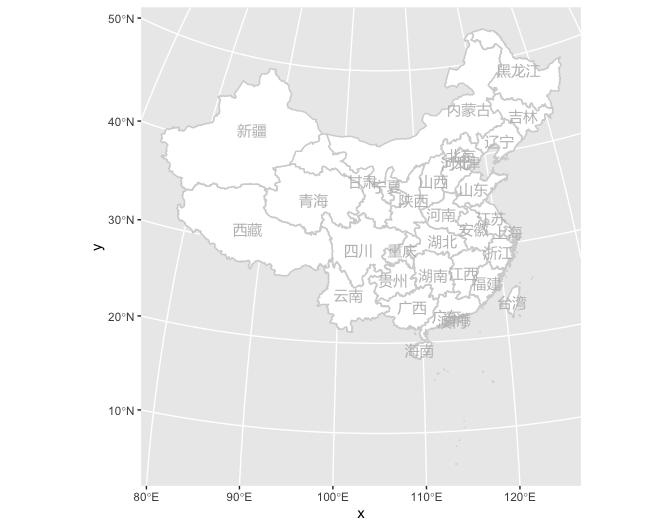

**Figure 2-2-2**: China Base Map by `geom_sf` (Province Level)

```r
map1 <- st_as_sf(cnmap1())
ggplot() +
    geom_sf(data=map1, fill='white', colour='lightgray') +
    geom_sf_text(aes(label=NAME_LAB), data=map1, colour='gray',
                 family="Microsoft YaHei") +
    coord_sf(crs=chn_crs)
```

## 2.3 Level-2 Base Map

Use dataset `chnmap2` to draw a level-2 China base map. Take `geom_sf` as exmaple.

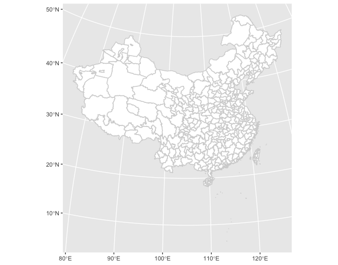

**Figure 2-3-1**: China Base Map (City Level)

```r
map2 <- st_as_sf(cnmap2())
ggplot() +
    geom_sf(data=map2, fill='white', colour='lightgray') +
    coord_sf(crs=chn_crs)
```

## 2.4 Level-3 Base Map

Use dataset `chnmap3` to draw a level-3 China base map. Take `geom_sf` as exmaple.

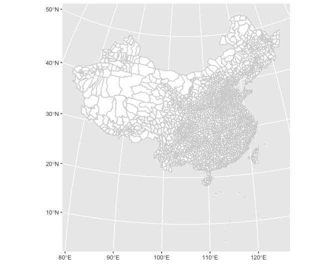

**Figure 2-4-1**: China Base Map (County Level)

```r
map3 <- st_as_sf(cnmap3())
ggplot() +
    geom_sf(data=map3, fill='white', colour='lightgray') +
    coord_sf(crs=chn_crs)
```

## 2.5 Mixed Base Map

By stacking layers of polygons/sf, you can get a mixed-level base map.

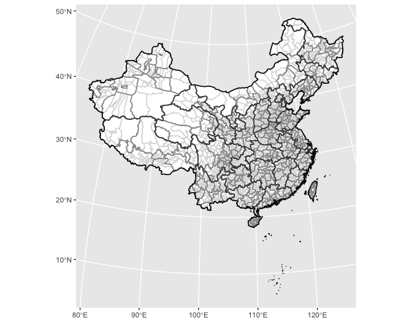

**Figure 2-5-1**: China Base Map - Mixed Levels

```r
ggplot() +
    geom_sf(data=map3, fill='white', colour='grey85') +
    geom_sf(data=map2, fill='transparent', colour='grey60') +
    geom_sf(data=map1, fill='transparent', colour='grey30') +
    geom_sf(data=map0, fill='transparent', colour='grey5') +
    coord_sf(crs=chn_crs)
```

## 2.6 Partial Base Map

You can also extract part of China to draw a map. For example, plot a submap of Guangdong + Hong Kong + Macau.

```r
suppressWarnings(library(dplyr))
knitr::kable(cnmap1()@data %>% filter(NAME_EN %in% c("Guangdong", "Hong Kong", "Macau")) %>%
    select(NAME, NAME_EN, ADCODE), caption=tn('ADCODE of GD, HK & MC', 2, sect=6))
```

**Table 2-6-1**: ADCODE of GD, HK & MC

| NAME | NAME_EN | ADCODE |
| --- | --- | --- |
| 澳门特别行政区 | Macau | 820000 |
| 广东省 | Guangdong | 440000 |
| 香港特别行政区 | Hong Kong | 810000 |

Now we know that ADCODE for these areas are “^44”, “^81” and “^82”. Here we go.

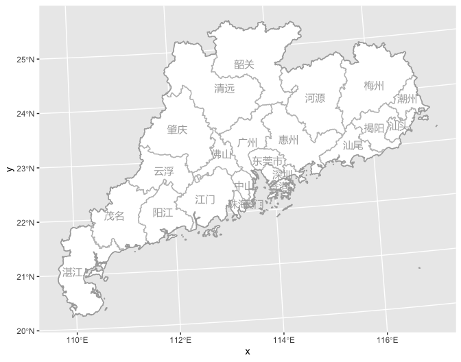

**Figure 2-7-1**: China Base Map with Labels - GD, HK & MC

```r
submap1 <- st_as_sf(cnmap1(regions=c("^44", "^8[12]")))
submap2 <- st_as_sf(cnmap2(regions=c("^44", "^8[12]")))
ggplot() +
    geom_sf(data=submap2, fill="white", color="gray") +
    geom_sf(data=submap1, fill="transparent", color="darkgray") +
    geom_sf_text(aes(label=NAME_LAB), data=submap2, colour='darkgray',
                 family="Microsoft YaHei") +
    coord_sf(crs=chn_crs)
```

The `regions` argument in `cnmap()` can match `NAME`, `NAME_EN`, `NAME_LAB` and `ADCODE`, so you mix all the regular expression patterns for fast filtering.

Besides, you can also `filter` the `sf` objects later in `geom_sf`, so as to reuse `sfmap1` and `sfmap2` more conveniently.

```r
sfmap1 <- st_as_sf(cnmap1())
sfmap2 <- st_as_sf(cnmap2())
ggplot() +
    geom_sf(data=sfmap2 %>% filter(grepl("^(44|8[12])", ADCODE)),
            fill="white", color="gray") +
    geom_sf(data=sfmap1 %>% filter(grepl("^(44|8[12])", ADCODE)),
            fill="transparent", color="darkgray") +
    geom_sf_text(aes(label=NAME_LAB),
                 data=sfmap2 %>% filter(grepl("^(44|8)", ADCODE)),
                 colour='darkgray', family="Microsoft YaHei") +
    coord_sf(crs=chn_crs)
```

# 3 Scatter Plots on A Map

Use embedded dataset ‘world.cities’ in `package:maps` to draw a scatterplot.

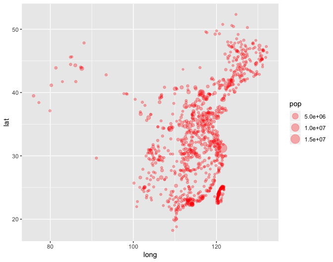

**Figure 3-1-1**: Big Cities of China on Cartesian Coordinate System

```r
data('world.cities')
big.cities <- world.cities[world.cities$country.etc %in% c('China', 'Taiwan'), ]
ggplot() +
    geom_point(aes(x=long, y=lat, size=pop), data=big.cities, color='red',
               alpha=0.3)
```

> Note that `geom_map` and `geom_polygon` apply WGS coordinate system. So if you have some data from Baidu, you should use `asesgeo::bd2wgs` function to convert the coordinates.

We have yielded a scatterplot in cartesian coordinate system. Now let’s plot it on top of a base map.

> Note: the ‘world.cities’ dataset applies the default CRS ‘EPSG:4326’ or 4326 (proj=longlat +ellps=WGS84 +datum=WGS84 +no_defs).

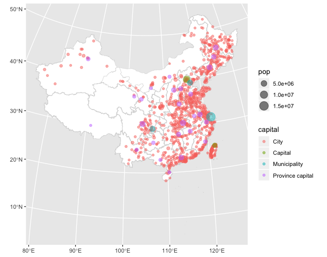

**Figure 3-1-2**: Big Cities of China

```r
big.cities$capital <- as.factor(big.cities$capital)
levels(big.cities$capital) <- c(
    'City', 'Capital', 'Municipality', 'Province capital')
big.cities <- st_as_sf(
    big.cities, coords=c("long", "lat"), crs="+init=epsg:4326", agr="constant")
ggplot() +
    geom_sf(data=map1, fill='white', color='gray85', size=0.2) +
    geom_sf(aes(size=pop, color=capital), data=big.cities, shape=19,
            alpha=0.5, show.legend="point") +
    coord_sf(crs=chn_crs)
```

# 4 Fortify the Map

## 4.1 Simplification

The original map dataset is bit large. Sometimes you may want to reduce the object size. You will need to turn on `simplify_level` argument in `cnmap()`.

```r
map1_simp1 <- cnmap1(simplify_level=0.05)
map1_simp2 <- cnmap1(simplify_level=0.05, drop_fragment=TRUE)

size_orig <- object.size(cnmap1()) / 1024^2
size_simp1 <- object.size(map1_simp1) / 1024^2
size_simp2 <- object.size(map1_simp2) / 1024^2
```

The simplifed map retaining islands is as below. `simplified_level`=0.05 means it will only keep 5% of the points.

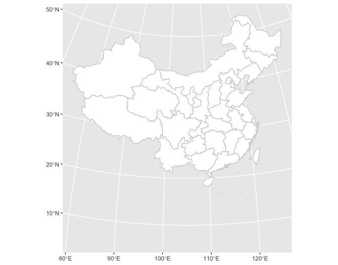

**Figure 4-1-1**: Simplified China Map (Retain Islands)

```r
ggplot() +
    geom_sf(data=st_as_sf(map1_simp1), fill='white', colour='lightgray') +
    coord_sf(crs=chn_crs)
```

The simplified map dropping small islands is as below – looks more concise.

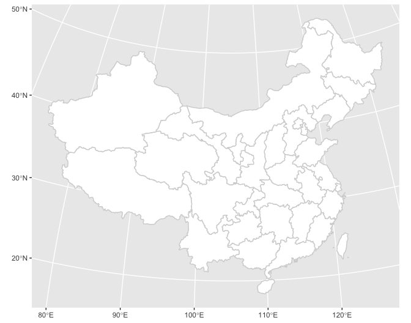

**Figure 4-1-2**: Simplified China Map (Drop Islands)

```r
ggplot() +
    geom_sf(data=st_as_sf(map1_simp2), fill='white', colour='lightgray') +
    coord_sf(crs=chn_crs)
```

How effective is it to reduce the object size?

**Table 4-1-1**: Object Size Before And After Simplification

[output not shown]

## 4.2 Fortification

Put a gray layer beneath the plot, to render the plot more ‘3-D’. You will need to do affine translations (see `vignette("sf3", "sf")`) first.

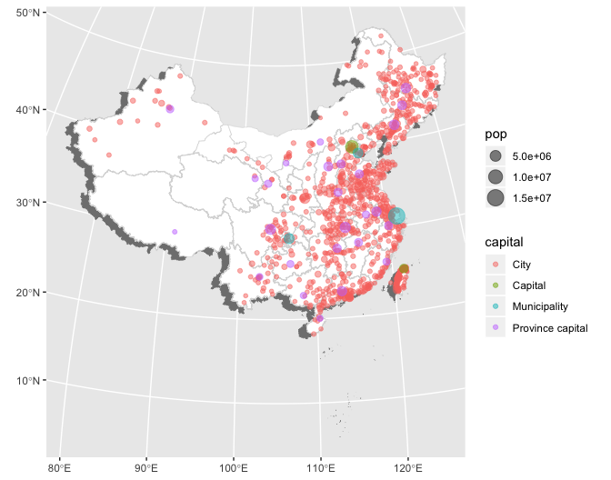

**Figure 4-2-1**: Big Cities of China - Shadow 3D

```r
# translate the geometry of map0 by 1 degree west and 0.5 degree south
map0_geom_translated <- st_geometry(map0) + c(-1, -0.5)
# apply the tranlated geometry
map0_bg <- st_set_geometry(map0, map0_geom_translated) %>%
    st_set_crs(st_crs(map0))
# add the translated geometry layer
ggplot() +
    geom_sf(data=map0_bg, fill='grey50', color='gray50', size=0.2) +
    geom_sf(data=map1, fill='white', color='gray85', size=0.2) +
    geom_sf(aes(size=pop, color=capital), data=big.cities, shape=19,
            alpha=0.5, show.legend="point") +
    coord_sf(crs=chn_crs)
```

# 5 Choropleth Plot

Use area of each city to plot a choropleth plot.

## 5.1 `geom_polygon`

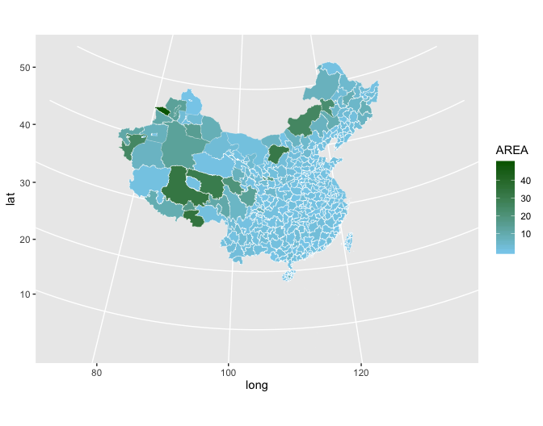

**Figure 5-1-1**: Size of China Cities using `geom_polygon`

```r
area.map <- fortify(cnmap2()) %>% left_join(
    cnmap2()@data %>% select(NAME, AREA, ID), by=c("id"="ID"))
ggplot() +
    geom_polygon(aes(x=long, y=lat, group=group, fill=AREA), data=area.map,
                 color='white', size=0.05) +
    scale_fill_gradient(low='skyblue', high='darkgreen') +
    coord_map('albers', parameters=c(24, 47))
```

## 5.2 `geom_sf`

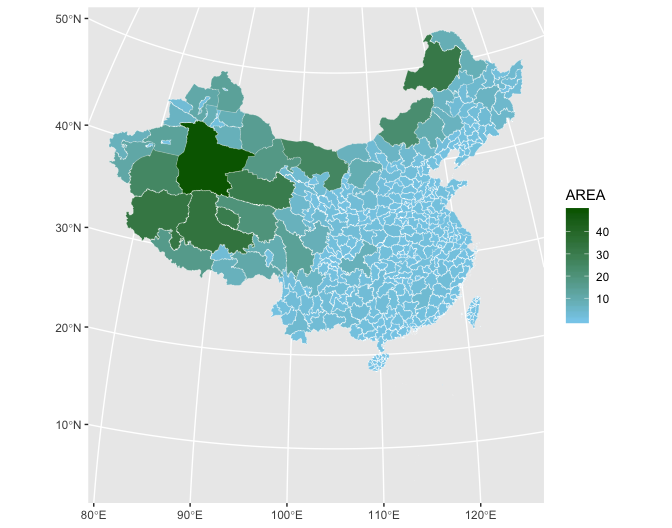

**Figure 5-2-1**: Size of China Cities using `geom_sf`

```r
ggplot() +
    geom_sf(aes(fill=AREA), data=map2, color='white', size=0.05) +
    scale_fill_gradient(low='skyblue', high='darkgreen') +
    coord_sf(crs=chn_crs)
```

A quick call for `sf` is simply `plot()`

```r
plot(map2['AREA'])
```

# 6 References

[^1]: http://gadm.org/ “Global Administrative Areas”
[^2]: Refer to ggplot2 official manual at https://ggplot2.tidyverse.org/reference/.